# week 2 assingment 11 - number x category penguin bivarate analysis

```python
import pandas as pd
```

```python
import seaborn as sns
```

## All coloumns

```python
penguins = sns.load_dataset("penguins")
penguins.head()
```

|  | species | island | bill_length_mm | bill_depth_mm | flipper_length_mm | body_mass_g | sex |
| --- | --- | --- | --- | --- | --- | --- | --- |
| 0 | Adelie | Torgersen | 39.1 | 18.7 | 181.0 | 3750.0 | Male |
| 1 | Adelie | Torgersen | 39.5 | 17.4 | 186.0 | 3800.0 | Female |
| 2 | Adelie | Torgersen | 40.3 | 18.0 | 195.0 | 3250.0 | Female |
| 3 | Adelie | Torgersen | NaN | NaN | NaN | NaN | NaN |
| 4 | Adelie | Torgersen | 36.7 | 19.3 | 193.0 | 3450.0 | Female |

## species grouping

```python
penguins.groupby('species').mean()
```

| species | bill_length_mm | bill_depth_mm | flipper_length_mm | body_mass_g |
| --- | --- | --- | --- | --- |
| Adelie | 38.791391 | 18.346358 | 189.953642 | 3700.662252 |
| Chinstrap | 48.833824 | 18.420588 | 195.823529 | 3733.088235 |
| Gentoo | 47.504878 | 14.982114 | 217.186992 | 5076.016260 |

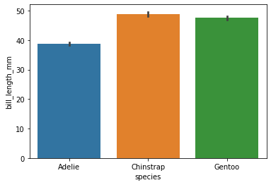

```python
sns.barplot(y="bill_length_mm", x="species", data=penguins)
```

The bill length of the adelie penguins are the shoretest. The confidence interval of the other two species overlap.

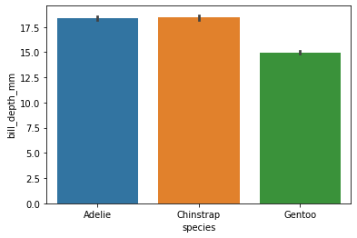

```python
sns.barplot(y="bill_depth_mm", x="species", data=penguins)
```

The bill depth of the Gentoo penguins are the smallest. Depth of the other two species are about equal.

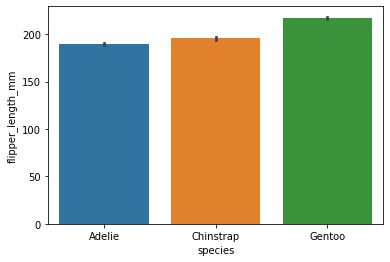

```python
sns.barplot(y="flipper_length_mm", x="species", data=penguins)
```

The Gentoo penguins also have the longest flippers. The confidence intervals of all the species is small.

## island grouping

```python
penguins.groupby('island').mean()
```

| island | bill_length_mm | bill_depth_mm | flipper_length_mm | body_mass_g |
| --- | --- | --- | --- | --- |
| Biscoe | 45.257485 | 15.874850 | 209.706587 | 4716.017964 |
| Dream | 44.167742 | 18.344355 | 193.072581 | 3712.903226 |
| Torgersen | 38.950980 | 18.429412 | 191.196078 | 3706.372549 |

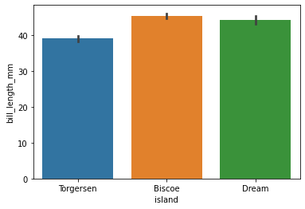

```python
sns.barplot(y="bill_length_mm", x="island", data=penguins)
```

the bill length of the torgersen island penguins seems to be shorter than the other two islands. The confidence interval of the biscoe island and the dream island pegnuins overlap.

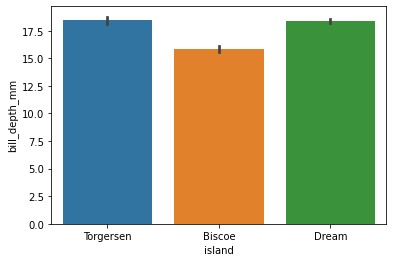

```python
sns.barplot(y="bill_depth_mm", x="island", data=penguins)
```

The bill depth of the Biscoe island penguins is the smallest. The confidence interval of the torgersen penguins is the bigest and overlaps with the dream island confidence.

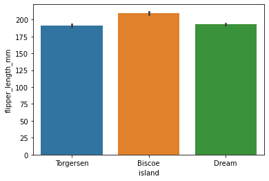

```python
sns.barplot(y="flipper_length_mm", x="island", data=penguins)
```

The flipper length of the biscoe island penguins are the longest. The flipper lenght of the other two island groups seem to be about the same

## sex grouping

```python
penguins.groupby('sex').mean()
```

| sex | bill_length_mm | bill_depth_mm | flipper_length_mm | body_mass_g |
| --- | --- | --- | --- | --- |
| Female | 42.096970 | 16.425455 | 197.363636 | 3862.272727 |
| Male | 45.854762 | 17.891071 | 204.505952 | 4545.684524 |

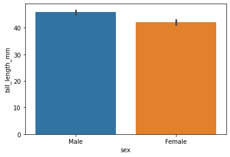

```python
sns.barplot(y="bill_length_mm", x="sex", data=penguins)
```

Male penguins have longer bills.

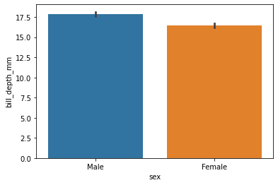

```python
sns.barplot(y="bill_depth_mm", x="sex", data=penguins)
```

Male penguins also have bigger bills.

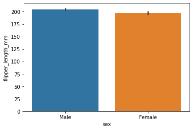

```python
sns.barplot(y="flipper_length_mm", x="sex", data=penguins)
```